# project_rmd

2022-11-08

## Data Science Covid Adventure

```r
library(tidyverse)
library(lubridate)
```

```r
library(dplyr)
library(ggplot2)
```

## 1. Importing the Data

Creating the URLs

```r
url_github <- "https://raw.githubusercontent.com/CSSEGISandData/COVID-19/master/csse_covid_19_data/csse_covid_19_time_series/"

file_names <- c("time_series_covid19_confirmed_global.csv","time_series_covid19_deaths_global.csv")

full_urls <- str_c(url_github, file_names)
```

Read Data into R

```r
cases <- read_csv(full_urls[1])
deaths <- read_csv(full_urls[2])
```

## 2. Formating the Data

Changing the Column names.

```r
cases <- cases %>% rename(Country = "Country/Region", Province = "Province/State")
deaths <- deaths %>% rename(Country = "Country/Region", Province = "Province/State")
```

Data is row based, we will Pivot it into the correct shape.

```r
cases_pivot <- cases %>% pivot_longer(cols = -c("Province", "Country", Lat, Long), names_to = "date", values_to = "cases") %>% select(-c(Lat,Long))
deaths_pivot <- deaths %>% pivot_longer(cols = -c("Province", "Country", Lat, Long), names_to = "date", values_to = "deaths") %>% select(-c(Lat,Long))
```

Joining the Death and Cases Data into a single DataFrame.

```r
global <- cases_pivot %>% full_join(deaths_pivot) %>% mutate(date = mdy(date))
```

Let’s look at a short summary of our data.

```r
summary(global)
```

```
##    Province           Country               date                cases
##  Length:295069      Length:295069      Min.   :2020-01-22   Min.   :       0
##  Class :character   Class :character   1st Qu.:2020-10-03   1st Qu.:     454
##  Mode  :character   Mode  :character   Median :2021-06-15   Median :   10891
##                                        Mean   :2021-06-15   Mean   :  801029
##                                        3rd Qu.:2022-02-25   3rd Qu.:  182633
##                                        Max.   :2022-11-07   Max.   :97780182
##      deaths
##  Min.   :      0
##  1st Qu.:      2
##  Median :    120
##  Mean   :  12191
##  3rd Qu.:   2561
##  Max.   :1072724
```

We can see 0 as a minimum which is plausible, let’s checl if the maximums are feasible.

```r
global %>% filter(cases > 95000000)
```

```
## # A tibble: 62 × 5
##    Province Country date          cases  deaths
##    <chr>    <chr>   <date>        <dbl>   <dbl>
##  1 <NA>     US      2022-09-07 95030572 1049261
##  2 <NA>     US      2022-09-08 95137693 1049949
##  3 <NA>     US      2022-09-09 95238504 1050496
##  4 <NA>     US      2022-09-10 95248621 1050534
##  5 <NA>     US      2022-09-11 95257606 1050554
##  6 <NA>     US      2022-09-12 95327128 1051015
##  7 <NA>     US      2022-09-13 95406852 1051534
##  8 <NA>     US      2022-09-14 95510510 1052505
##  9 <NA>     US      2022-09-15 95593873 1053176
## 10 <NA>     US      2022-09-16 95650114 1053608
## # … with 52 more rows
```

```r
global %>% filter(deaths > 1000000)
```

```
## # A tibble: 183 × 5
##    Province Country date          cases  deaths
##    <chr>    <chr>   <date>        <dbl>   <dbl>
##  1 <NA>     US      2022-05-09 82138934 1000213
##  2 <NA>     US      2022-05-10 82209658 1000540
##  3 <NA>     US      2022-05-11 82370700 1001224
##  4 <NA>     US      2022-05-12 82476172 1001526
##  5 <NA>     US      2022-05-13 82563440 1001733
##  6 <NA>     US      2022-05-14 82581561 1001793
##  7 <NA>     US      2022-05-15 82614682 1001830
##  8 <NA>     US      2022-05-16 82791646 1002077
##  9 <NA>     US      2022-05-17 82877118 1002474
## 10 <NA>     US      2022-05-18 83081000 1003445
## # … with 173 more rows
```

Yes they seem to be okay.

## 3. Analysis

### Totals

Let’s get some insights on the total amount of cases and deaths per Country.

```r
global_totals <- global %>% group_by(Country) %>% summarise(total_cases = sum(cases), total_deaths = sum(deaths))

cases_totals <-  global_totals %>% arrange(desc(total_cases))
death_totals <-  global_totals %>% arrange(desc(total_deaths))
```

Now that we have that, why don’t we check the Top 10 of each Category.

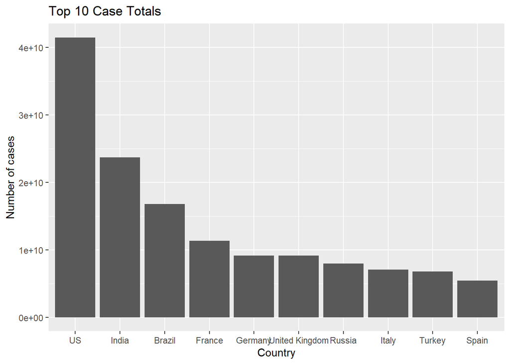

```r
top_cases <- cases_totals %>% slice(1:10) %>% .$Country
top_deaths <- death_totals %>% slice(1:10) %>% .$Country

cases_totals %>% slice(1:10)  %>% ggplot(., aes(x=factor(Country, level = top_cases), y=total_cases))+ geom_bar(stat='identity') + labs(title = "Top 10 Case Totals",x="Country", y="Number of cases")
```

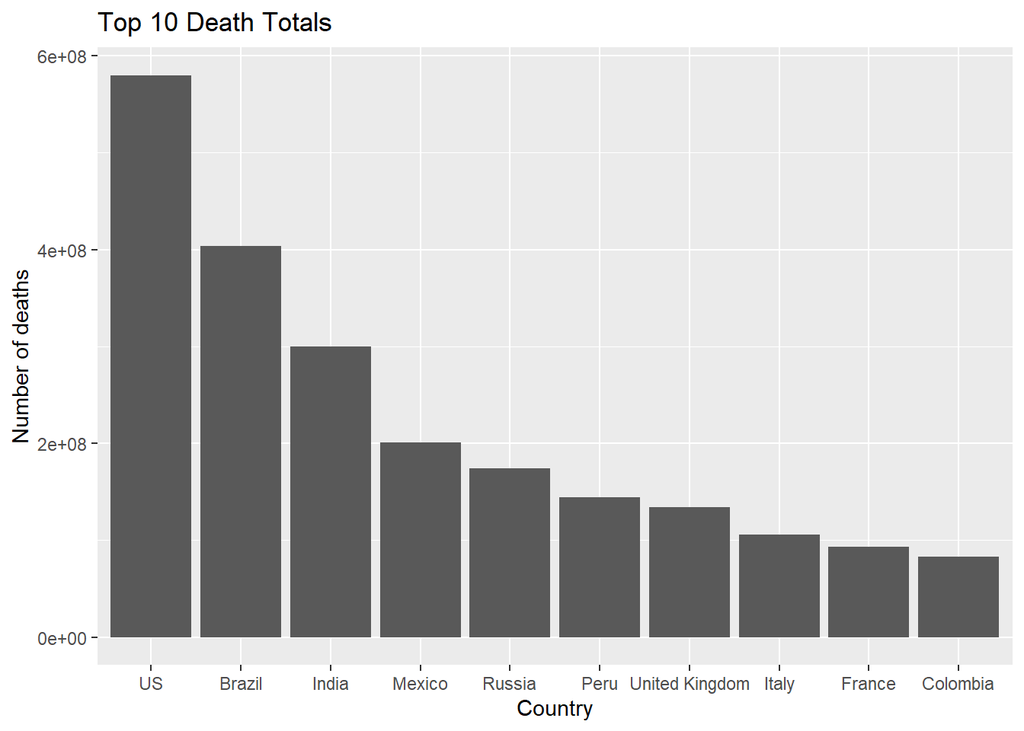

```r
death_totals %>% slice(1:10)  %>% ggplot(., aes(x=factor(Country, level = top_deaths), y=total_deaths))+ geom_bar(stat='identity') + labs(title = "Top 10 Death Totals",x="Country", y="Number of deaths")
```

Interesting. We can see the top 10 are mostly by similar Countries. US is first in deaths and cases for example, but some don’t have matching spots. Let’s look into it further.

### Difference

```r
death_totals$death_pos <- seq.int(nrow(death_totals))
cases_totals$cases_pos <- seq.int(nrow(cases_totals))
total_pos <- merge(cases_totals,death_totals)
total_pos$dif <- total_pos$cases_pos - total_pos$death_pos
total_pos <-  total_pos %>% arrange(desc(dif))
total_pos$fac <-  scales::percent(total_pos$total_deaths / total_pos$total_cases)
```

```r
total_stats <- total_pos
total_stats$total_cases <- NULL
total_stats$total_deaths <- NULL
```

#### Top 10 by difference

```r
total_stats <- total_stats %>% arrange(fac)
total_stats %>% slice(1:10)
```

```
##                 Country cases_pos death_pos dif        fac
## 1            Antarctica       199       197   2 0.0000000%
## 2                Tuvalu       200       200   0 0.0000000%
## 3              Holy See       197       198  -1 0.0000000%
## 4  Summer Olympics 2020       195       199  -4 0.0000000%
## 5  Winter Olympics 2022       196       201  -5 0.0000000%
## 6                 Nauru       194       196  -2 0.0212874%
## 7                Bhutan       153       186 -33 0.0384521%
## 8                 Tonga       186       191  -5 0.0882897%
## 9           New Zealand        76       142 -66 0.0990238%
## 10              Iceland       123       174 -51 0.1021712%
```

```r
total_pos <- total_pos %>% arrange(fac)
# remove Winter Olympics/non countries
total_pos <- total_pos %>% slice(-c(2, 3, 4, 5))


total_stats <-total_stats %>% arrange(desc(fac))
total_pos <-total_pos %>% arrange(desc(fac))
total_stats %>% slice(1:10)
```

```
##                   Country cases_pos death_pos dif          fac
## 1                    Peru        24         6  18   7.3434349%
## 2                   Sudan       132        89  43   7.3117109%
## 3            Korea, North       201       195   6 600.0000000%
## 4                  Mexico        16         4  12   6.5647953%
## 5                   Syria       139       100  39   5.9453604%
## 6                   Egypt        85        37  48   5.2349880%
## 7                 Somalia       154       122  32   5.0345345%
## 8                 Ecuador        64        26  38   4.8180935%
## 9             Afghanistan       109        70  39   4.2631293%
## 10 Bosnia and Herzegovina        94        51  43   4.2114728%
```

```r
#remove NK for having more deaths than cases
total_pos <- total_pos %>% slice(-c(3))
```

So let’s look at the top 10 for each side. Countries where they have much higher Deaths to Cases ratio and the other way.

#### Top 10 by difference

```r
total_pos %>% arrange(desc(fac)) %>% slice(1:10)
```

```
##                   Country total_cases total_deaths cases_pos death_pos dif
## 1                    Peru  1962440277    144110525        24         6  18
## 2                   Sudan    35165422      2571194       132        89  43
## 3                  Mexico  3056258753    200637132        16         4  12
## 4                   Syria    28202815      1676759       139       100  39
## 5                   Egypt   271690631     14222972        85        37  48
## 6                 Somalia    14533141       731676       154       122  32
## 7                 Ecuador   457759863     22055298        64        26  38
## 8             Afghanistan   104674634      4462415       109        70  39
## 9  Bosnia and Herzegovina   198647585      8365989        94        51  43
## 10                Liberia     4043404       168674       180       152  28
##           fac
## 1  7.3434349%
## 2  7.3117109%
## 3  6.5647953%
## 4  5.9453604%
## 5  5.2349880%
## 6  5.0345345%
## 7  4.8180935%
## 8  4.2631293%
## 9  4.2114728%
## 10 4.1715841%
```

```r
total_pos %>% arrange(fac) %>% slice(1:10)
```

```
##             Country total_cases total_deaths cases_pos death_pos dif        fac
## 1        Antarctica        3619            0       199       197   2 0.0000000%
## 2             Nauru      605993          129       194       196  -2 0.0212874%
## 3            Bhutan    14698800         5652       153       186 -33 0.0384521%
## 4             Tonga     2966370         2619       186       191  -5 0.0882897%
## 5       New Zealand   334057981       330797        76       142 -66 0.0990238%
## 6           Iceland    56978872        58216       123       174 -51 0.1021712%
## 7         Singapore   455465321       482259        65       129 -64 0.1058827%
## 8  Marshall Islands     1238274         1389       191       194  -3 0.1121723%
## 9           Burundi    16783528        18995       150       183 -33 0.1131764%
## 10            Palau     1354188         1620       189       193  -4 0.1196289%
```

## 4. Country Analysis and model

### Analysis

Germany and Italy are countries with very different covid policies. So let’s compare the two.

```r
geit <- filter(global, Country == "Germany" |  Country == "Italy")
italy <- filter(global,Country == "Italy")
germany <- filter(global,Country == "Germany")
```

#### Cases over time

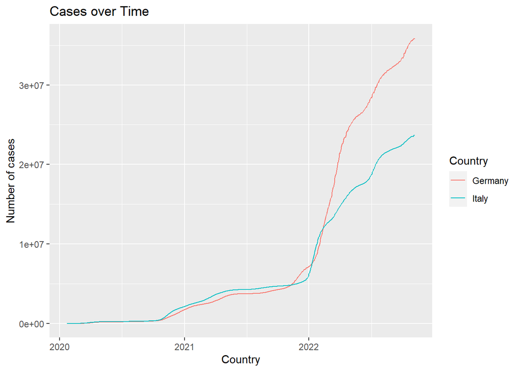

```r
ggplot(geit, aes(x=date, y=cases, group=Country, color=Country)) + geom_line() + labs(title = "Cases over Time",x="Country", y="Number of cases")
```

#### Deaths over time

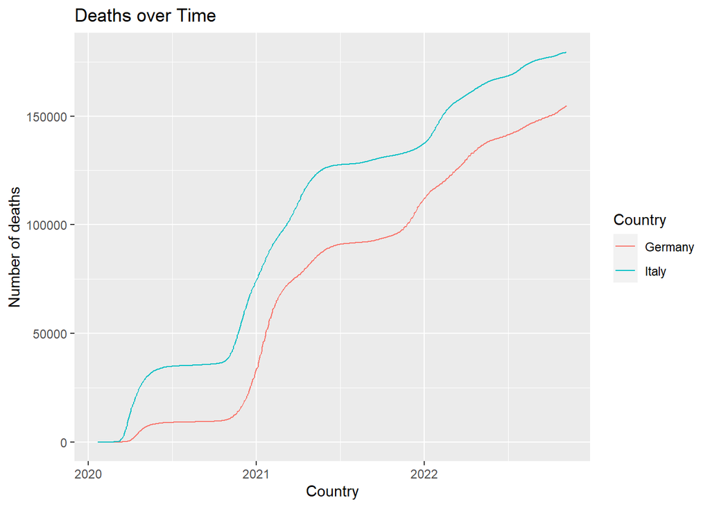

```r
ggplot(geit, aes(x=date, y=deaths, group=Country, color=Country)) +geom_line() + labs(title = "Deaths over Time",x="Country", y="Number of deaths")
```

#### ML Model

```r
mod <- lm(deaths ~ date, data=germany)
germany$pred <- predict(mod)


modi <- lm(deaths ~ date, data=italy)
germany$predi <- predict(modi)
```

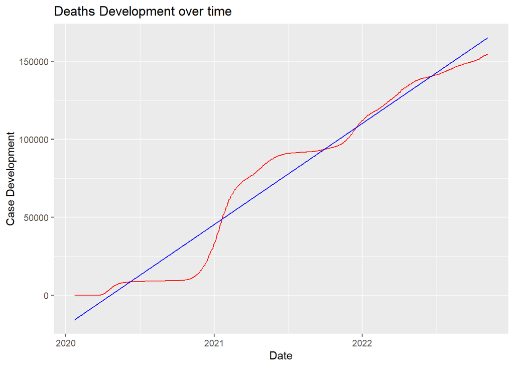

```r
ggplot(germany,aes(x=date)) + geom_line(aes(y = deaths), color="red") + geom_line(aes(y = pred), color="blue") + labs(title = "Deaths Development over time",x="Date", y="Case Development")
```